```python
from google.colab import drive
drive.mount('/content/drive')
```

```python
!pip install tensorflow==2.8
```

[output not shown]

# This is a VGG16 structure which is a cnn model. Here we only use the feature extraction part. It also worths noting that the model in keras library has been trained on nearly one million data and the weights are already tuned.

```python
from keras.models import Sequential
from keras.layers import Dense, Conv2D, MaxPool2D , Flatten
model = Sequential()
model.add(Conv2D(input_shape=(224,224,3),filters=64,kernel_size=(3,3),padding="same", activation="relu"))
model.add(Conv2D(filters=64,kernel_size=(3,3),padding="same", activation="relu"))
model.add(MaxPool2D(pool_size=(2,2),strides=(2,2)))
model.add(Conv2D(filters=128, kernel_size=(3,3), padding="same", activation="relu"))
model.add(Conv2D(filters=128, kernel_size=(3,3), padding="same", activation="relu"))
model.add(MaxPool2D(pool_size=(2,2),strides=(2,2)))
model.add(Conv2D(filters=256, kernel_size=(3,3), padding="same", activation="relu"))
model.add(Conv2D(filters=256, kernel_size=(3,3), padding="same", activation="relu"))
model.add(Conv2D(filters=256, kernel_size=(3,3), padding="same", activation="relu"))
model.add(MaxPool2D(pool_size=(2,2),strides=(2,2)))
model.add(Conv2D(filters=512, kernel_size=(3,3), padding="same", activation="relu"))
model.add(Conv2D(filters=512, kernel_size=(3,3), padding="same", activation="relu"))
model.add(Conv2D(filters=512, kernel_size=(3,3), padding="same", activation="relu"))
model.add(MaxPool2D(pool_size=(2,2),strides=(2,2)))
model.add(Conv2D(filters=512, kernel_size=(3,3), padding="same", activation="relu"))
model.add(Conv2D(filters=512, kernel_size=(3,3), padding="same", activation="relu"))
model.add(Conv2D(filters=512, kernel_size=(3,3), padding="same", activation="relu"))
model.add(MaxPool2D(pool_size=(2,2),strides=(2,2)))
model.add(Flatten())
model.summary()
```

```
Model: "sequential"
_________________________________________________________________
 Layer (type)                Output Shape              Param #
=================================================================
 conv2d (Conv2D)             (None, 224, 224, 64)      1792

 conv2d_1 (Conv2D)           (None, 224, 224, 64)      36928

 max_pooling2d (MaxPooling2D  (None, 112, 112, 64)     0
 )

 conv2d_2 (Conv2D)           (None, 112, 112, 128)     73856

 conv2d_3 (Conv2D)           (None, 112, 112, 128)     147584

 max_pooling2d_1 (MaxPooling  (None, 56, 56, 128)      0
 2D)

 conv2d_4 (Conv2D)           (None, 56, 56, 256)       295168

 conv2d_5 (Conv2D)           (None, 56, 56, 256)       590080

 conv2d_6 (Conv2D)           (None, 56, 56, 256)       590080

 max_pooling2d_2 (MaxPooling  (None, 28, 28, 256)      0
 2D)

 conv2d_7 (Conv2D)           (None, 28, 28, 512)       1180160

 conv2d_8 (Conv2D)           (None, 28, 28, 512)       2359808

 conv2d_9 (Conv2D)           (None, 28, 28, 512)       2359808

 max_pooling2d_3 (MaxPooling  (None, 14, 14, 512)      0
 2D)

 conv2d_10 (Conv2D)          (None, 14, 14, 512)       2359808

 conv2d_11 (Conv2D)          (None, 14, 14, 512)       2359808

 conv2d_12 (Conv2D)          (None, 14, 14, 512)       2359808

 max_pooling2d_4 (MaxPooling  (None, 7, 7, 512)        0
 2D)

 flatten (Flatten)           (None, 25088)             0

=================================================================
Total params: 14,714,688
Trainable params: 14,714,688
Non-trainable params: 0
_________________________________________________________________
```

```python
from tensorflow.keras.applications import VGG16
conv_base = VGG16(weights='imagenet',
                  include_top=False,
                  input_shape=(224, 224, 3))
```

```
Downloading data from https://storage.googleapis.com/tensorflow/keras-applications/vgg16/vgg16_weights_tf_dim_ordering_tf_kernels_notop.h5
```

# We now load the images and true labels

```python
from keras.preprocessing import image
from keras.applications.vgg16 import preprocess_input
import numpy as np
import os
import pandas as pd

image_dir = "/content/drive/MyDrive/Flower_images"

image_files = [os.path.join(image_dir, f) for f in os.listdir(image_dir) if os.path.isfile(os.path.join(image_dir, f))]
features_list = []
df = pd.read_csv("/content/drive/MyDrive/flower_labels.csv")
y = []

for img_path in image_files:
    img = image.load_img(img_path,target_size=(224,224))
    selected_row = (df[df['file'] == img_path[-8:]])
    label = selected_row['label'].iloc[0]
    y.append(label)
    # print(label)
    x = image.img_to_array(img)
    # print(x.shape)
    x = np.expand_dims(x,axis = 0)
    # print(x.shape)
    x = preprocess_input(x)
    # print(x.shape)
    features = conv_base.predict(x)
    # print(features.shape)
    # print(f"feature vector shape is : {features.shape}")
    features_list.append(features)
```

```python
print(y)
```

```
[0, 0, 2, 0, 0, 1, 6, 0, 0, 0, 0, 0, 0, 7, 7, 1, 0, 0, 6, 0, 2, 4, 7, 4, 5, 6, 2, 5, 6, 6, 6, 5, 0, 3, 8, 5, 9, 2, 8, 1, 7, 3, 1, 4, 7, 3, 8, 1, 3, 4, 7, 9, 3, 6, 5, 8, 6, 8, 2, 1, 7, 8, 0, 5, 6, 3, 6, 4, 9, 7, 9, 1, 5, 3, 6, 6, 8, 3, 1, 4, 3, 9, 8, 5, 2, 4, 6, 4, 7, 1, 5, 2, 1, 5, 8, 5, 3, 1, 2, 4,…
```

# Implemmenting the Kmeans algorithm on the feature vectors which are not reduced yet. We also normalize the features vectors using standardScaler

```python
from sklearn.cluster import KMeans
from sklearn.preprocessing import StandardScaler, MinMaxScaler

feature_vectors = np.array(features_list)
print(feature_vectors.shape)
feature_vectors = np.reshape(feature_vectors, (210, -1))
print(feature_vectors.shape)


scaler = StandardScaler()
feature_vectors = scaler.fit_transform(feature_vectors)


num_clusters = 10

kmeans = KMeans(n_clusters=num_clusters,n_init=10)
kmeans.fit(feature_vectors)

cluster_labels = kmeans.labels_
```

```
(210, 1, 7, 7, 512)
(210, 25088)
```

# Implemmenting pca which is a approach of dimension reduction on the feature vectors exracted from VGG16 net

```python
from sklearn.decomposition import PCA
feature_vectors = np.array(features_list)
print(feature_vectors.shape)
feature_vectors = np.reshape(feature_vectors, (210, -1))
print(feature_vectors.shape)
pca = PCA(n_components=2,
          svd_solver='randomized',
          random_state=42)

reduced_feature_vectors_2d = pca.fit_transform(feature_vectors)

print(reduced_feature_vectors_2d.shape)
```

```
(210, 1, 7, 7, 512)
(210, 25088)
(210, 2)
```

# Implemmenting the DBSCAN alogorithm on the features vectors which have not been reduced yet

```python
from sklearn.cluster import DBSCAN
import matplotlib.pyplot as plt

dbscan = DBSCAN(eps=2000, min_samples=1)
dbscan.fit(feature_vectors)
cluster_labels = dbscan.labels_
plt.figure(figsize=(8, 6))
unique_labels = np.unique(cluster_labels)
```

# Visualizing reduced data points after applying PCA

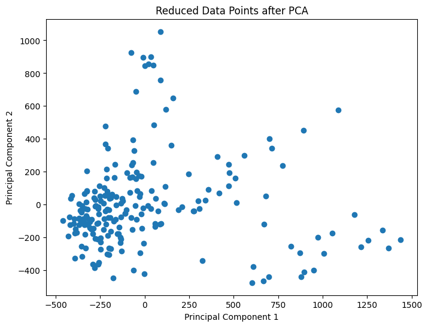

```python
import matplotlib.pyplot as plt

plt.figure(figsize=(8, 6))
plt.scatter(reduced_feature_vectors_2d[:, 0], reduced_feature_vectors_2d[:, 1])
plt.title('Reduced Data Points after PCA')
plt.xlabel('Principal Component 1')
plt.ylabel('Principal Component 2')
plt.show()
```

# Implemmenting TSNE which is another approach of dimension reduction just to see the difference.

```
(210, 2)
```

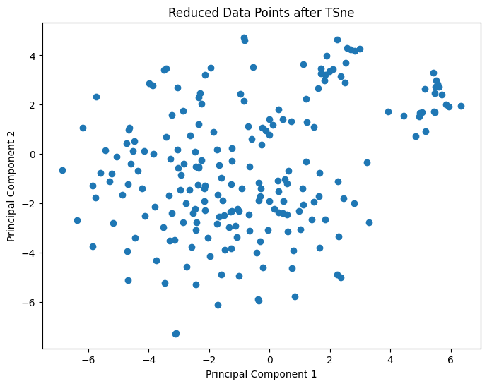

```python
from sklearn.manifold import TSNE

tsne = TSNE(n_components=2,  # Number of components to reduce to
            perplexity=30,    # The perplexity hyperparameter (suggested range: 5 to 50)
            learning_rate=50,  # The learning rate hyperparameter (suggested range: 10 to 1000)
            n_iter=2000,     # Number of iterations (suggested range: 250 to 1000)
            random_state=42)  # Random seed for reproducibility

reduced_feature_vectors_2d_tsne = tsne.fit_transform(feature_vectors)

print(reduced_feature_vectors_2d_tsne.shape)
# Plot the reduced data points
plt.figure(figsize=(8, 6))
plt.scatter(reduced_feature_vectors_2d_tsne[:, 0], reduced_feature_vectors_2d_tsne[:, 1])
plt.title('Reduced Data Points after TSne')
plt.xlabel('Principal Component 1')
plt.ylabel('Principal Component 2')
plt.show()
```

# Now we want to plot the reduced data points with their true labels

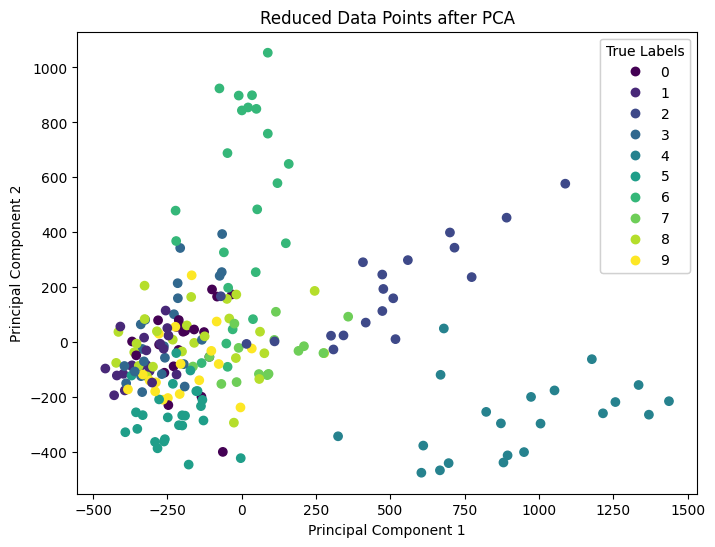

```python
import matplotlib.pyplot as plt
import pandas as pd

true_labels_df = pd.read_csv("/content/drive/MyDrive/flower_labels.csv")
true_labels = true_labels_df['label'].values

plt.figure(figsize=(8, 6))
scatter = plt.scatter(reduced_feature_vectors_2d[:, 0], reduced_feature_vectors_2d[:, 1], c=y)
plt.title('Reduced Data Points after PCA')
plt.xlabel('Principal Component 1')
plt.ylabel('Principal Component 2')

legend1 = plt.legend(*scatter.legend_elements(), title='True Labels')
plt.gca().add_artist(legend1)

plt.show()
```

# Implemmenting kmeans on the reduced feature vectors after PCA

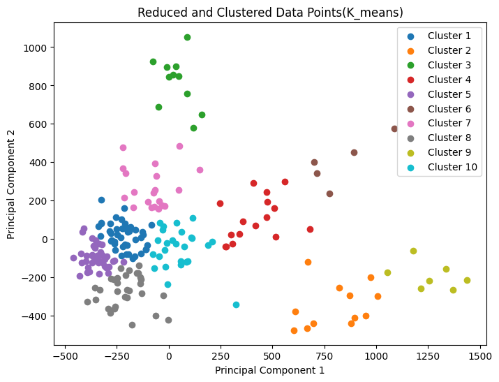

```python
from sklearn.cluster import KMeans

import matplotlib.pyplot as plt
num_clusters = 10
kmeans = KMeans(n_clusters=num_clusters,n_init=10)
kmeans.fit(reduced_feature_vectors_2d)
cluster_labels = kmeans.labels_

plt.figure(figsize=(8, 6))
for cluster in range(num_clusters):
    plt.scatter(reduced_feature_vectors_2d[cluster_labels == cluster, 0], reduced_feature_vectors_2d[cluster_labels == cluster, 1], label=f'Cluster {cluster+1}')
plt.title('Reduced and Clustered Data Points(K_means)')
plt.xlabel('Principal Component 1')
plt.ylabel('Principal Component 2')
plt.legend()
plt.show()
```

# Implemmenting DBSCAN on the reduced feature vectors after PCA

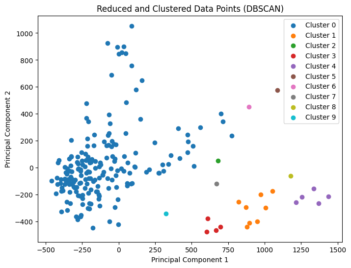

```python
from sklearn.cluster import DBSCAN
dbscan = DBSCAN(eps=165, min_samples=1)
dbscan.fit(reduced_feature_vectors_2d)
cluster_labels = dbscan.labels_

plt.figure(figsize=(8, 6))
unique_labels = np.unique(cluster_labels)
for label in unique_labels:
    if label == -1:  # Noise points
        plt.scatter(reduced_feature_vectors_2d[cluster_labels == label, 0], reduced_feature_vectors_2d[cluster_labels == label, 1], color='gray', label='Noise')
    else:
        plt.scatter(reduced_feature_vectors_2d[cluster_labels == label, 0], reduced_feature_vectors_2d[cluster_labels == label, 1], label=f'Cluster {label}')
plt.title('Reduced and Clustered Data Points (DBSCAN)')
plt.xlabel('Principal Component 1')
plt.ylabel('Principal Component 2')
plt.legend()
plt.show()
```

# Silhouette and Homogenity score between the reduced kmeans labels and true labels

```python
import pandas as pd
from sklearn.metrics import homogeneity_score

csv_file_path = "/content/drive/MyDrive/flower_labels.csv"
cluster_labels_df = pd.read_csv(csv_file_path)

true_labels = cluster_labels_df["label"].values
print(y, kmeans.labels_)

homogeneity = homogeneity_score(y, kmeans.labels_)
print("Homogeneity Score:", homogeneity)
```

[output not shown]

```python
silhouette = silhouette_score(reduced_feature_vectors_2d, kmeans.labels_)
print("Silhouette Score:", silhouette)
```

```
Silhouette Score: 0.376237
```

# Method here for determinning the number of clusters is Elbow method. For doing so, we can pick a result cluster number that the WCSS differences after which are negligible.

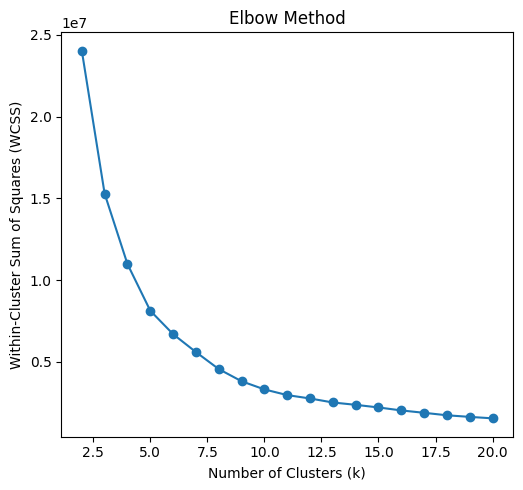

```python
import numpy as np
import matplotlib.pyplot as plt
from sklearn.cluster import KMeans
from sklearn.metrics import silhouette_score

k_values = range(2, 21)
wcss_scores = []
silhouette_scores = []

for k in k_values:
    kmeans = KMeans(n_clusters=k, random_state=42, n_init=10)
    kmeans.fit(reduced_feature_vectors_2d)
    wcss_scores.append(kmeans.inertia_)

plt.figure(figsize=(10, 5))
plt.subplot(1, 2, 1)
plt.plot(k_values, wcss_scores, marker='o')
plt.xlabel('Number of Clusters (k)')
plt.ylabel('Within-Cluster Sum of Squares (WCSS)')
plt.title('Elbow Method')


plt.tight_layout()
plt.show()
```

# Silhoutte and Homogenity score between the reduced DBSCAN labels and true labels

```python
import pandas as pd
from sklearn.metrics import homogeneity_score

csv_file_path = "/content/drive/MyDrive/flower_labels.csv"
cluster_labels_df = pd.read_csv(csv_file_path)

true_labels = cluster_labels_df["label"].values

print(cluster_labels, y)

homogeneity = homogeneity_score(y, cluster_labels)
print("Homogeneity Score:", homogeneity)
```

```
[0 0 0 0 0 0 0 0 0 0 0 0 0 0 0 0 0 0 0 0 0 1 0 2 0 0 0 0 0 0 0 0 0 0 0 0 0
 0 0 0 0 0 0 3 0 0 0 0 0 1 0 0 0 0 0 0 0 0 0 0 0 0 0 0 0 0 0 4 0 0 0 0 0 0
 0 0 0 0 0 4 0 0 0 0 5 1 0 1 0 0 0 6 0 0 0 0 0 0 0 4 0 0 0 0 0 0 0 0 4 0 0
 0 0 0 0 0 0 0 0 7 0 0 0 0 0 0 0 0 0 3 0 0 0 0 0 4 0 8 0 0 0 0 0 1 0 0 9 0
 0 0 0 0 0 0 0 0 0 0 0 0 0 0 0 0 0 0 0 0 0 0 0 0 3 0 0 0 0 0 0 0 0 0 0 0 0
 1 0 0 0 0 0 0 0 0 3 0 0 0 0 1 0 0 1 0 0 0 0 0 0 0] [0, 0, 2, 0, 0, 1, 6, 0, 0, 0, 0, 0, 0, 7, 7, 1, 0, 0, 6, 0, 2, 4, 7, 4, 5, 6, 2, 5, 6, 6, 6, 5, 0, 3, 8, 5, 9, 2, 8, 1, 7, 3, 1, 4, 7, 3, 8, 1, 3, 4, 7, 9, 3, 6, 5, 8, 6, 8, 2, 1, 7, 8, 0, 5, 6, 3, 6, 4, 9, 7, 9, 1, 5, 3, 6, 6, 8, 3, 1, 4, 3, 9, 8…
Homogeneity Score: 0.151617594401874
```

```python
import pandas as pd
from sklearn.metrics import silhouette_score

csv_file_path = "/content/drive/MyDrive/flower_labels.csv"
cluster_labels_df = pd.read_csv(csv_file_path)

true_labels = cluster_labels_df["label"].values

silhouette = silhouette_score(reduced_feature_vectors_2d, dbscan.labels_)
print("Silhouette Score:", silhouette)
```

```
Silhouette Score: 0.28693086
```

# Silhouette and Homogenity score between the kmeans labels and true labels

```python
kmeans2 = KMeans(n_clusters=num_clusters,n_init=10)
kmeans2.fit(feature_vectors)
cluster_labels2 = kmeans2.labels_

csv_file_path = "/content/drive/MyDrive/flower_labels.csv"
cluster_labels_df = pd.read_csv(csv_file_path)

true_labels = cluster_labels_df["label"].values

homogeneity = homogeneity_score(y, cluster_labels2)
print("Homogeneity Score:", homogeneity)
```

```
Homogeneity Score: 0.515470587075723
```

```python
silhouette = silhouette_score(feature_vectors, cluster_labels2)
print("Silhouette Score:", silhouette)
```

```
Silhouette Score: 0.021985091
```

# Homogenity score between the DBSCAN labels and true labels

```python
dbscan2 = DBSCAN(eps=0.8, min_samples=3)
dbscan2.fit(feature_vectors)
cluster_labels3 = dbscan2.labels_

csv_file_path = "/content/drive/MyDrive/flower_labels.csv"
cluster_labels_df = pd.read_csv(csv_file_path)

true_labels = cluster_labels_df["label"].values

homogeneity = homogeneity_score(y, cluster_labels3)
print("Homogeneity Score:", homogeneity)
```

```
Homogeneity Score: 0.0
```